# Reporte de Polución para martires y Bogotá

Periodo: 2024-12-31 a 2025-01-30

## martires

#### Polución general

Para **martires** la polución promedio del mes fue de 11.51 microgramos por metro cúbico, con 7 días arriba del límite recomendado. Esto lo coloca como la 13va localidad con más polución y como la 14va con más días arriba del límite recomendado. .

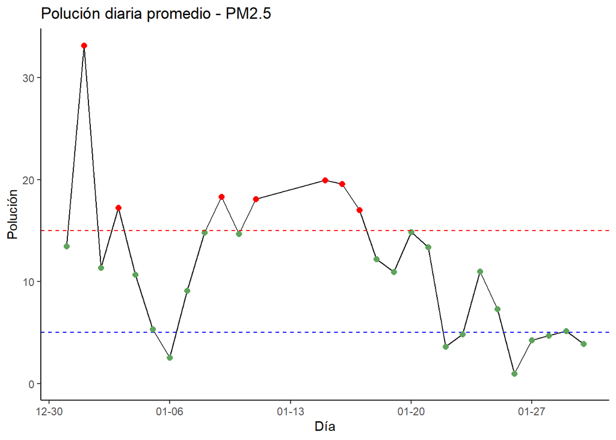

La localidad cuenta con 3 escuelas en el estudio. A continuación se muestra la polución para cada una de las escuelas de la localidad, indicando los días por arriba del límite recomendado.

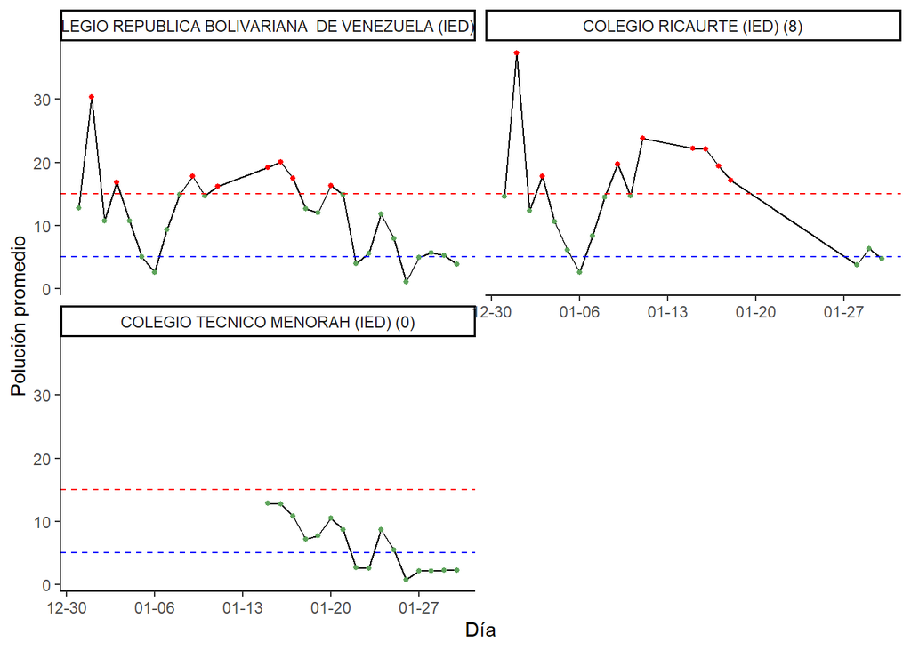

#### Polución por escuela

##### Polución mensual promedio

[interactive chart not shown]

| Escuela | PM2.5 | Dias arriba del límite |
| --- | --- | --- |
| COLEGIO REPUBLICA BOLIVARIANA DE VENEZUELA (IED) | 11.78 | 8 |
| COLEGIO RICAURTE (IED) | 16.43 | 8 |
| COLEGIO TECNICO MENORAH (IED) | 6.19 | 0 |

##### Polución afuera y adentro

Las escuelas tienen monitores de polución adentro y afuera de los salones. A continuación presentamos la polución promedio diaria en ambos puntos (afuera y adentro) para cada escuela, e indicamos aquellas que tienen filtro de aire . Los huecos en la gráfica se deben a datos faltantes, que indican que alguno de los sensores no funcionó ese día.

**Escuelas con filtro**

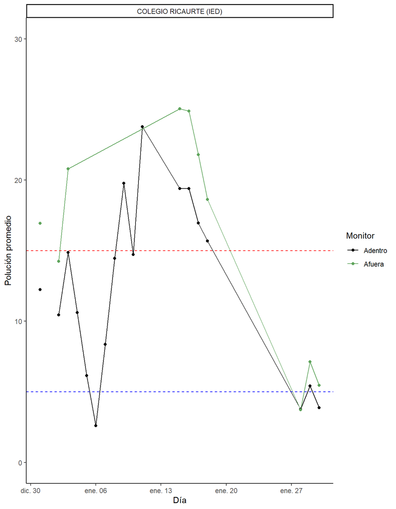

**Escuelas sin filtro**

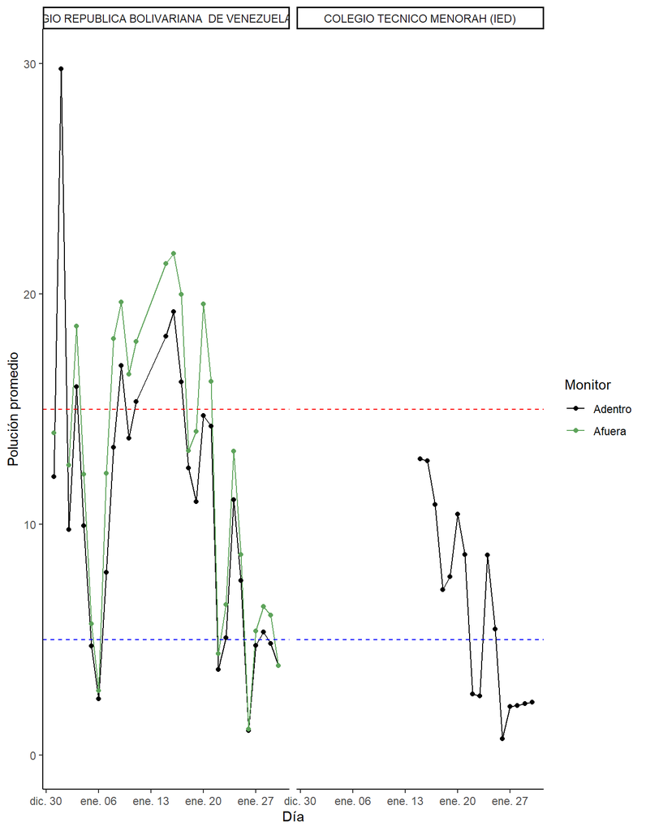

Adicionalmente, comparamos la polución promedio tanto adentro como afuera para las escuelas con filtros y sin filtros.

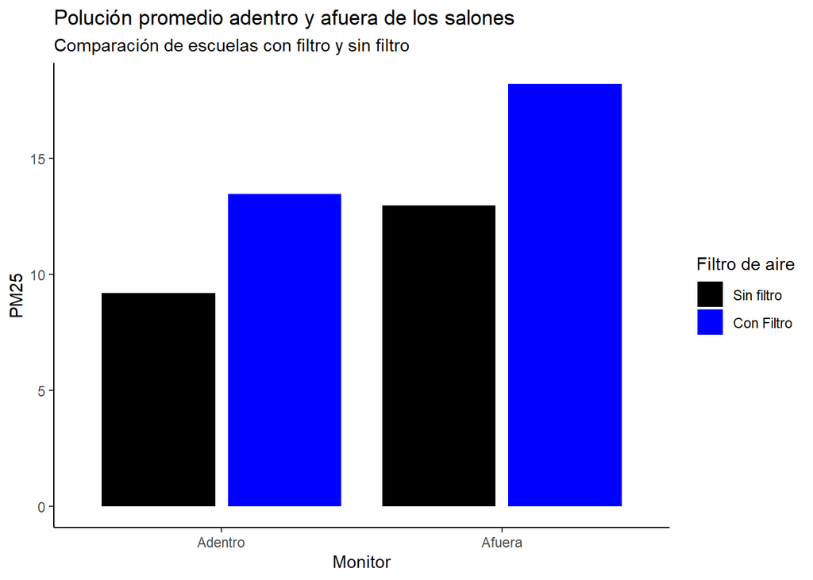

#### Uso de los filtros

Para aquellas escuelas de la localidad que tienen filtros de aire, es posible que en realidad no estén siendo utilizados. A continuación presentamos estas escuelas junto con la probabilidad de que estén utilizando sus filtros de aire, ordenadas de la menos probable a la más probable. Esto para ayudar a identificar y corregir aquellas escuelas que no están utilizando sus filtros.

| Escuela | Probabilidad de uso | Riesgo |
| --- | --- | --- |
| COLEGIO RICAURTE (IED) | 1 | ✅ |

#### Estado de los sensores

A continuación presentamos el diagnóstico de los monitores de polución, identificando lo siguiente:

- **Porcentaje de uso**: ¿Cuántas mediciones realizó sobre el total que debería realizar en los 31 días?
- **Número de días sin mediciones**: ¿Cuántos días el monitor no registró *ninguna* medida?
- **Status del sensor**: Presentamos la salud del sensor con base en el siguiente criterio
  - Ok: Registró al menos 85% de las lecturas, y no más de 5 días sin lecturas
  - En riesgo: Registró entre 50% y 85% de las lecturas, o 5-10 días sin lecturas
  - Fallando: Registró menos del 50% de las lecturas o más de 10 días sin lecturas

| Sede | Sensor | Está en el exterior | Porcentaje de lecturas | Dias sin registro | Status |
| --- | --- | --- | --- | --- | --- |
| COLEGIO RICAURTE (IED) | externo | Sí | 30.13 | 17 | 🔴 |
| COLEGIO TECNICO MENORAH (IED) | 306 | No | 50.93 | 12 | 🔴 |
| COLEGIO RICAURTE (IED) | s210 | No | 57.70 | 9 | 🔶 |
| COLEGIO REPUBLICA BOLIVARIANA DE VENEZUELA (IED) | socia | No | 94.35 | 0 | ✅ |
| COLEGIO REPUBLICA BOLIVARIANA DE VENEZUELA (IED) | scpt | No | 94.46 | 0 | ✅ |
| COLEGIO REPUBLICA BOLIVARIANA DE VENEZUELA (IED) | exter | Sí | 94.68 | 0 | ✅ |

## Bogotá

#### Polución mensual promedio

[interactive chart not shown]

| Localidad | PM2.5 |
| --- | --- |
| ANTONIO NARIÑO | 13.55 |
| BARRIOS UNIDOS | 9.54 |
| BOSA | 16.61 |
| CIUDAD BOLIVAR | 17.78 |
| ENGATIVA | 12.45 |
| FONTIBON | 13.81 |
| KENNEDY | 15.35 |
| MARTIRES | 11.51 |
| PUENTE ARANDA | 13.28 |
| RAFAEL URIBE URIBE | 14.06 |
| SAN CRISTOBAL | 12.89 |
| SANTA FE | 14.67 |
| SUBA | 11.94 |
| TUNJUELITO | 12.70 |
| USAQUEN | 7.38 |
| USME | 9.78 |

#### Días arriba del límite recomendado

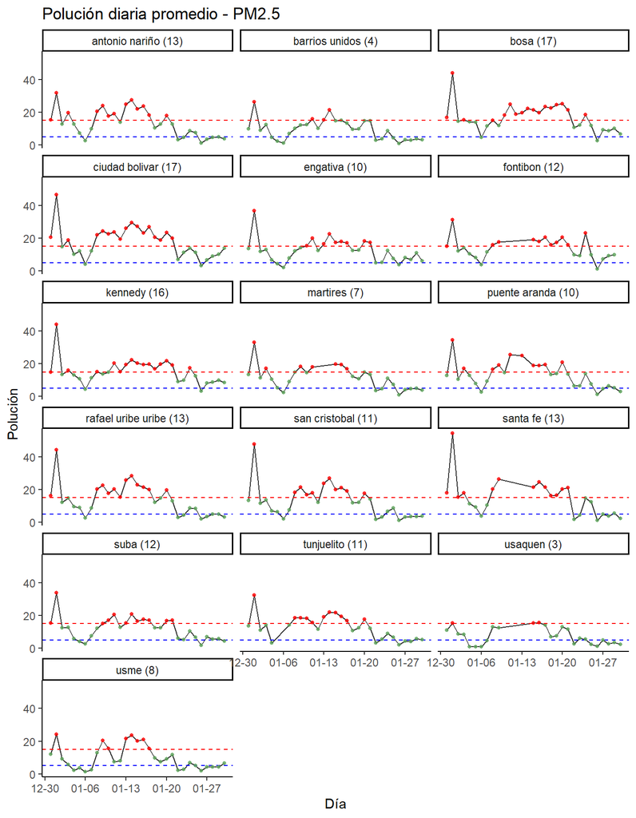